# Machine Learning Safety

## Extract deep features for your in-distribution validation images

## Use the same model whose MSP you evaluated in Exercise 9.6

Take the pedestrian model and remove its last classification layer.

We did not use the final classifier output (pedestrian/not pedestrian).

- Instead, we used the ResNet feature extractor.
- For every image: loaded the image, preprocessed it, passed it through ResNet up to the layer before the FC layer,
- extracted the resulting 512-dimensional feature vector,
- and stored it.

```python
feature_extractor = torch.nn.Sequential(*list(ped_model.children())[:-1]).to(device)
feature_extractor.eval()
```

[output not shown]

[output cut: 28 more lines]

[output not shown]

extract id ref features

```python
def extract_features(folder):
    features = []

    with torch.no_grad():
        for img_name in sorted(os.listdir(folder)):

            if not img_name.endswith(('.jpg', '.png', '.jpeg')):
                continue

            img_path = os.path.join(folder, img_name)

            img = Image.open(img_path).convert("RGB")
            img = transform(img).unsqueeze(0).to(device)

            feat = feature_extractor(img)
            feat = torch.flatten(feat, 1)

            features.append(feat.cpu().numpy().squeeze())

    return np.array(features)
```

extract 512 dimensional features from x validation images

```python
validation_folder = "/Users/maverick/Documents/Notes/Machine Learning Safety/ML Safety Files/ML safety 2026 datasets/validation/rgb-front"

validation_features = extract_features(validation_folder)

print(validation_features.shape)
```

```
(3600, 512)
```

now fit the KNN detector on these 3600 images

```python
from sklearn.neighbors import NearestNeighbors

knn = NearestNeighbors(n_neighbors=5)

knn.fit(validation_features)

print("k-NN fitted!")
```

```
k-NN fitted!
```

extract features from evaluation datasets

```python
id_features = extract_features(id_folder)
fog_features = extract_features(fog_folder)
night_features = extract_features(night_folder)

print(id_features.shape)
print(fog_features.shape)
print(night_features.shape)
```

```
(3600, 512)
(3600, 512)
(3600, 512)
```

Now compute the k-NN OOD scores (mean distance to the 5 nearest neighbors)

```python
id_scores = knn.kneighbors(id_features)[0].mean(axis=1)
fog_scores = knn.kneighbors(fog_features)[0].mean(axis=1)
night_scores = knn.kneighbors(night_features)[0].mean(axis=1)
```

cehck the averages

```python
print("ID:", id_scores.mean())
print("Fog:", fog_scores.mean())
print("Night:", night_scores.mean())
```

```
ID: 0.21661509203310642
Fog: 0.19638931259057588
Night: 0.3984159960341122
```

Now compute KNN AURoc

```python
from sklearn.metrics import roc_auc_score

ood_scores = np.concatenate([fog_scores, night_scores])

y_true = np.concatenate([
    np.zeros(len(id_scores)),
    np.ones(len(ood_scores))
])

y_score = np.concatenate([
    id_scores,
    ood_scores
])

auroc_knn = roc_auc_score(y_true, y_score)

print("k-NN AUROC:", auroc_knn)
```

```
k-NN AUROC: 0.8168025462962962
```

That means k-NN worked much better than MSP.

MSP AUROC: 0.351

k-NN AUROC: 0.817

1] MSP asks: "How confident is the classifier?"

2] k-NN asks: "Does this image look similar to normal images?"

3] we learned that Confidence is not a reliable indicator of OOD.

- because, The pedestrian model was very confident on night images, even though they were OOD.
- BUT, Their deep features were far away from normal validation images, so k-NN could detect them.

4] So, the main takeaway from this is, Feature-space methods (k-NN) can detect OOD inputs much better than relying only on classifier confidence (MSP).

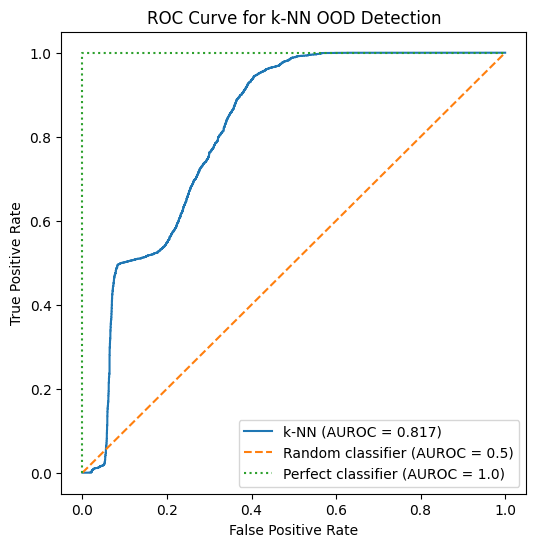

```python
from sklearn.metrics import roc_curve, roc_auc_score

# Combine OOD scores
ood_scores = list(fog_scores) + list(night_scores)

# Labels: 0 = ID, 1 = OOD
y_true = [0] * len(id_scores) + [1] * len(ood_scores)

# k-NN: larger distance → more OOD
y_score_knn = list(id_scores) + ood_scores

# Compute AUROC and ROC curve
auroc_knn = roc_auc_score(y_true, y_score_knn)
fpr_knn, tpr_knn, _ = roc_curve(y_true, y_score_knn)

# Plot
plt.figure(figsize=(6, 6))
plt.plot(fpr_knn, tpr_knn, label=f"k-NN (AUROC = {auroc_knn:.3f})")
plt.plot([0, 1], [0, 1], '--', label="Random classifier (AUROC = 0.5)")
plt.plot([0, 0, 1], [0, 1, 1], ':', label="Perfect classifier (AUROC = 1.0)")

plt.xlabel("False Positive Rate")
plt.ylabel("True Positive Rate")
plt.title("ROC Curve for k-NN OOD Detection")
plt.legend()
plt.show()
```